# Challenge 2 - Visualization of Energy Consumptions

Challenger: Kazuki Minamiya

```python
#! /usr/bin/env python
# -*- coding:utf-8 -*-
import numpy as np
import scipy.stats as st
import matplotlib.pyplot as plt
from matplotlib.colors import ListedColormap
import pylab
import pandas as pd
from sklearn.cluster import KMeans
from datetime import datetime as dt
```

### 0. Download the data-set total-watt.csv

First, I read total_watt.csv as pandas dataframe.

```python
df_total_watt = pd.read_csv('../../data/total_watt.csv',
                            parse_dates=['Timestamp'],
                            names=['Timestamp','Energy'],
                            header=0,
                            index_col='Timestamp')
colors = ['#FFEE99','#FF9922','#FF4422']
```

```python
df_total_watt.head()
```

| Timestamp | Energy |
| --- | --- |
| 2011-04-18 13:52:00 | 483.295892 |
| 2011-04-18 14:22:00 | 915.761634 |
| 2011-04-18 14:52:00 | 609.043491 |
| 2011-04-18 15:22:00 | 745.155434 |
| 2011-04-18 15:52:00 | 409.855947 |

5 rows × 1 columns

### 1. visualization of the data-set as values per 30mins

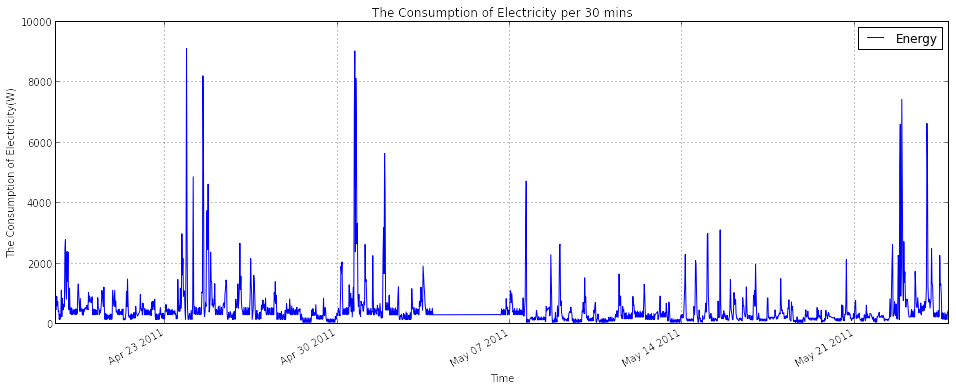

```python
f = plt.figure(figsize=(16, 6))
df_total_watt.plot(ax=f.gca())
plt.xlabel('Time')
plt.ylabel('The Consumption of Electricity(W)')
plt.title('The Consumption of Electricity per 30 mins')
plt.show()
```

In this chart, the data-set as values per 30 mins is visualized with a line graph. From the chart, I could know the tow points below:

- The data-set is lacking in some days (May 04 and May 05)
- A few points have abnormally high energy consumption.

### 2. visualization of the data-set as values per day

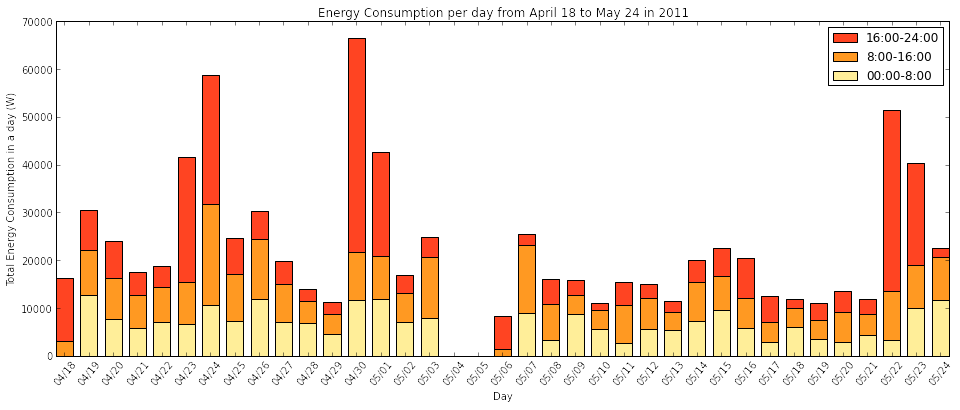

```
The Pearson correlation coefficients between energy consumption of three groups and energy consumption of all day
    Time     PCC
00:00-08:00 0.574
08:00-16:00 0.715
16:00-24:00 0.936
```

```python
date = pd.date_range('2011-04-18', '2011-05-24')
energy_per_8hour = np.zeros([4, len(date)])
for i, one_date in enumerate(date[:]):
    one_date = one_date.strftime('%Y-%m-%d')
    energy_per_8hour[0,i] = df_total_watt[one_date:one_date+' 08:00:00'].sum()
    energy_per_8hour[1,i] = df_total_watt[one_date+' 08:00:00':one_date+' 16:00:00'].sum()
    energy_per_8hour[2,i] = df_total_watt[one_date+' 16:00:00':one_date].sum()
    energy_per_8hour[3,i] = df_total_watt[one_date].sum()
ind = np.arange(len(date))
width = 0.7
plt.figure(figsize=(16, 6))
p1 = plt.bar(ind, energy_per_8hour[0], width, color=colors[0])
p2 = plt.bar(ind, energy_per_8hour[1], width, color=colors[1], bottom=energy_per_8hour[0])
p3 = plt.bar(ind, energy_per_8hour[2], width, color=colors[2], bottom=energy_per_8hour[0]+energy_per_8hour[1])
plt.xlabel('Day')
plt.ylabel('Total Energy Consumption in a day (W)')
plt.title('Energy Consumption per day from April 18 to May 24 in 2011')
plt.xticks(ind+width/2., [dt.strftime(i, '%m/%d') for i in date], rotation=50)
plt.legend( (p3[0], p2[0], p1[0]), ('16:00-24:00', '8:00-16:00', '00:00-8:00'))
plt.autoscale(enable=True, axis='x',tight=True)
plt.show()

### Calculating Pearson correlation coefficients between energy consumption of three groups with it of all day
energy_per_8hour=np.delete(energy_per_8hour, [0,16,17,18,36], 1)
corr = np.corrcoef([energy_per_8hour[0], energy_per_8hour[1], energy_per_8hour[2], energy_per_8hour[3]])
print 'The Pearson correlation coefficients between energy consumption of three groups and energy consumption of all day'
print '    Time    '+ ' PCC'
print '00:00-08:00 '+ str(round(corr[3,0], 3))
print '08:00-16:00 '+ str(round(corr[3,1], 3))
print '16:00-24:00 '+ str(round(corr[3,2], 3))
```

In this chart, the data-set as values per day is visualized with a stacked bar chart(0:00-8:00, 8:00-16:00, 16:00-24:00). From the chart, I thought whether energy consumption in a day was high or not depended heavily on night-time (16:00-24:00). To confirm the hypothesis, I evaluated peason correlation coefficients between energy consumption of each three group and energy consumption of all day. Before the test, the data of 04/18, 05/04, 05/05, 05/06 and 05/24 were removed due to a lack of data for the test. As a consequence, It was found the energy consumption of all day had a strong correlation with energy consumption in 16:00-24:00(*PCC was 0.936).

### 3.visualization of the data-set as clusters

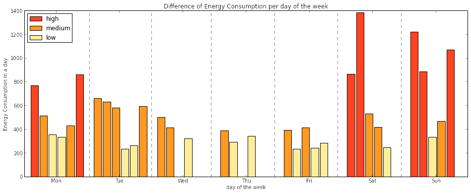

```python
days = pd.Series('Mon Tue Wed Thu Fri Sat Sun'.split())
df_energy_per_day = df_total_watt.resample('d', how='mean')
kmeans = KMeans(n_clusters=3)
kmeans.fit([[x] for x in df_energy_per_day.Energy.fillna(0).tolist()])
df_energy_per_day['label']=kmeans.labels_

# For sorting label (;;)
depd = df_energy_per_day
label_sorted = sorted([depd.ix[depd.label == i].ix[0][0] for i in range(3)])
color_sorted = [0]*3
for i, label in enumerate(map(lambda x: depd.ix[depd.Energy == x].ix[0][1], label_sorted)):
    color_sorted[int(label)]=colors[i]

plt.figure(figsize=(16, 6))
for day in df_energy_per_day.groupby(lambda x: x.weekday):
    for row in range(day[1].Energy.count()):
        color = color_sorted[int(day[1].iloc[[ row]].label)]
        plt.bar(0.1+ day[0] + float(row)/7, day[1].iloc[[ row]].Energy, 0.12, color=color)

plt.xticks(np.arange(0.5,7.5,1), days)
for x in [1.03,2.01,2.95,3.95,4.95,5.95]:
    plt.axvline(x=x, linestyle='--', color='grey')
plt.xlabel('day of the week')
plt.ylabel('Energy Consumption in a day')
plt.title('Difference of Energy Consumption per day of the week')

p = [0]*3
for i in range(3):
    p[i] = plt.Rectangle((0, 0), 1, 1, fc=colors[i])
plt.legend([p[2],p[1],p[0]], ["high","medium","low"], loc=2)
plt.show()
```

In this chart, the data is clustered in three groups (high, medium and low) using the kmeans algorithm, and the result is showen with a bar chart per day of the week. The chart shows the weekly variation of energy consumption per day of the week in a quantitative way.

### (Optional problem 1) What graghs is the most useful for consumer?

What is the most useful information for consumer is when they use much energy. Time and day of the week are periodic so that from relationship with them, consumers can know when they use much energy in a week.

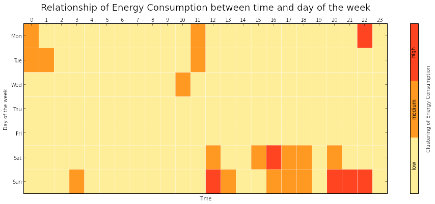

```python
days_and_time = np.zeros([7, 24])
for day in np.arange(0,7,1):
    for time in np.arange(0,24,1):
        days_and_time[day][time]=df_total_watt.ix[(df_total_watt.Energy.weekday == day) & (df_total_watt.index.hour == time)].mean()

fig, ax = plt.subplots(figsize=(16,6))
cMap = ListedColormap([colors[0],colors[1],colors[2]])
heatmap = ax.pcolor(days_and_time, cmap=cMap,edgecolors='w')
cbar = plt.colorbar(heatmap)
cbar.ax.get_yaxis().set_ticks([])

for j, lab in enumerate(['low','medium','high']):
    cbar.ax.text(.5, (2 * j + 1) / 6.0, lab, ha='center', va='center', rotation=90)
cbar.ax.get_yaxis().labelpad = 15
cbar.ax.set_ylabel('Clustering of Energy Consumption', rotation=90)

ax.set_xticks(np.arange(days_and_time.shape[1])+0.5, minor=False)
ax.set_yticks(np.arange(days_and_time.shape[0])+0.5, minor=False)

ax.invert_yaxis()
ax.xaxis.tick_top()
ax.axis('tight')
ax.set_xticklabels(np.arange(0,24,1), minor=False)
ax.set_yticklabels(days, minor=False)
plt.xlabel('Time')
plt.ylabel('Day of the week')
plt.text(0.5, 1.08, 'Relationship of Energy Consumption between time and day of the week',
        horizontalalignment='center',
        fontsize=18,
        transform = ax.transAxes)
plt.show()
```

In this chart, relationship between time and day of the week are shown with heatmap(high, medium and low). From the chart, it is found that this consumer uses much energy on Saturday and Sunday from 0 p.m. to 10 p.m., and it is a very natural result. However he(she) also uses much energy on Monday at 10 p.m. This information may be very useful for him(her) to reduce the energy consumption because energy is consumed specifically at the time.

### (Optional Problem 2) What is the most interesting visualizaion through this challenge ?

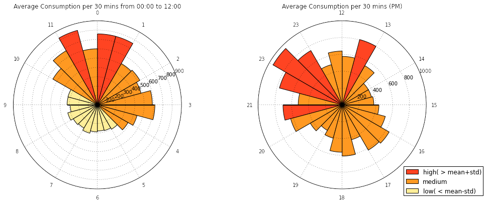

```python
energy_per_time=[]
for h in range(24):
    energy_per_time.append(df_total_watt.at_time('%d:22:00'%(h)).Energy.mean())
    energy_per_time.append(df_total_watt.at_time('%d:52:00'%(h)).Energy.mean())
N=24
theta = np.arange(0.0, 2*np.pi, 2*np.pi/N)
width = np.ones(N)*2*np.pi/N
std=np.std(np.array(energy_per_time))
mean=np.array(energy_per_time).mean()

plt.figure(figsize=(16, 6))

radii_am = np.r_[energy_per_time[5::-1], energy_per_time[23:5:-1]]

ax_am = plt.subplot(1,2,1, polar=True)
plt.thetagrids(np.arange(0, 360, 360/12), labels=[3,2,1,0,11,10,9,8,7,6,5,4])
ax_am.set_title("Average Consumption per 30 mins from 00:00 to 12:00", va='bottom')
bars_am = ax_am.bar(theta, radii_am, width=width, bottom=0)

radii_pm =  np.r_[energy_per_time[29:23:-1], energy_per_time[47:29:-1]]
ax_pm = plt.subplot(1,2,2, polar=True)
plt.thetagrids(np.arange(0, 360, 360/12), labels=[15,14,13,12,23,23,21,20,19,18,17,16])
ax_pm.set_title("Average Consumption per 30 mins (PM)", va='bottom')
bars_pm = ax_pm.bar(theta, radii_pm, width=width, bottom=0)

std=np.std(np.array(energy_per_time))
mean=np.array(energy_per_time).mean()
for r, bar in zip(radii_am, bars_am)+ zip(radii_pm, bars_pm):
    if mean+std<r: bar.set_facecolor(colors[2])
    elif mean-std<r<mean + std: bar.set_facecolor(colors[1])
    else: bar.set_facecolor(colors[0])

plt.legend([p[2],p[1],p[0]], ["high( > mean+std)","medium","low( < mean-std)"], bbox_to_anchor=(0.85, 0.15), loc=2)
plt.show()
```

In this graph, the data-set is shown with polar pie chart as values per 30 mins. This graph can make you easily understand at which time energy is consumed. I think that this graph may not be practicable, but interesting.